# Probability of Technical Success - EPO IV/SC QW/TIW

Metrum Research Group

```r
source("../src/global.R")
source("../src/functions.R")
future::plan(future::multiprocess)
library(mrgsolve)
library(tidyverse)
library(future.apply)
Sys.setenv(R_FUTURE_FORK_ENABLE=TRUE)
set.seed(112)
```

**Population Pharmacokinetic and Pharmacodynamic Model- Based Comparability Assessment of a Recombinant Human Epoetin Alfa and the Biosimilar HX575**

- Xiaoyu Yan, MS, Philip J. Lowe, PhD, Martin Fink, PhD, Alexander Berghout, PhD, Sigrid Balser, PhD, and Wojciech Krzyzanski, PhD
- J Clin Pharmacol. 2012 November ; 52(11): 1624–1644.
- https://www.ncbi.nlm.nih.gov/pubmed/22162538

# 1 Read in data …

```r
post <- readRDS("../data/epo_post.RDS") %>% sample_n(nrow(.))

post <- select(post, contains("THETA"))

head(post)
```

```
.   THETA1  THETA2 THETA3 THETA4 THETA5 THETA6 THETA7  THETA8 THETA9 THETA10
. 1  2.842 0.02584  4.672 0.4129 0.6604      0  12.26 0.07113 0.1787   40.08
. 2  2.650 0.03061  4.570 0.4297 0.4842      0  12.25 0.05405 0.1751   37.50
. 3  2.965 0.02902  4.477 0.4593 0.5385      0  12.09 0.05641 0.1753   37.93
. 4  2.672 0.02508  4.482 0.5012 0.6152      0  13.05 0.07455 0.1772   39.43
. 5  3.123 0.02546  4.595 0.3788 0.5044      0  12.43 0.06948 0.1768   39.42
. 6  2.568 0.02594  4.710 0.3773 0.6085      0  12.85 0.06307 0.1736   36.42
.   THETA11 THETA12 THETA13 THETA14 THETA15 THETA16 THETA17 THETA18 THETA19
. 1       0   68.90       0       0   7.935 0.12080   344.6   1.249   3.910
. 2       0   66.22       0       0   6.140 0.09632   430.7   1.479   3.841
. 3       0   66.39       0       0   6.227 0.09356   408.8   1.192   3.841
. 4       0   65.00       0       0   8.696 0.09887   261.3   1.123   3.857
. 5       0   69.82       0       0   7.643 0.13640   369.4   1.258   3.863
. 6       0   63.99       0       0   5.414 0.09680   468.8   1.534   3.842
.   THETA20
. 1   29.05
. 2   30.51
. 3   30.01
. 4   30.27
. 5   30.40
. 6   30.64
```

```r
dim(post)
```

```
. [1] 10000    20
```

# 2 … and the model

```r
mod <- mread_cache("epo", "../model") %>% zero_re()
see(mod)
```

```
.
. Model file:  epo.cpp
. [ PROB ]
. 1: Yan X, Lowe PJ, Fink M, Berghout A, Balser S, Krzyzanski W. Population
. pharmacokinetic and pharmacodynamic model-based comparability assessment of a
. recombinant human Epoetin Alfa and the Biosimilar HX575. J Clin Pharmacol. 2012
. Nov;52(11):1624-44. doi: 10.1177/0091270011421911. Epub 2011 Dec 12.
. PubMed PMID: 22162538; PubMed Central PMCID: PMC3483448.
.
. https://www.ncbi.nlm.nih.gov/pubmed/22162538
.
. $CMT @annotated
. A1 : EPO SC
. A2 : EPO SERUM
. A3 : EPO TISSUE
. A4 : PRECURSOR 1
. A5 : PRECURSOR 2
. A6 : PRECURSOR 3
. A7 : RET
. A8 : RBC
. A9 : HGB
.
.
. $OMEGA @annotated
. ED1   : 4.20E-01 : .
. EKA   : 1.11E-01 : .
. EVC   : 9.59E-02 : .
. ECL   : 2.92E-01 : .
. EC0   : 4.17E-02 : .
. ERET0 : 7.60E-02 : .
. ETP1  : 0.00E+00 : .
. ESC50 : 0.00E+00 : .
. ESMAX : 8.44E-01 : .
. EKD   : 0.00E+00 : .
. EKSAI : 1.80E-01 : .
. ERBC0 : 2.84E-03 : .
. EMCH  : 1.86E-03 : .
.
. $SIGMA
. 5.24E-02 0 7.70E-02  1.11E-03
```

[output cut: 86 more lines]

```
. double EPOdv = EPOi*(1+EPS(1))+EPS(2);
.
. capture RETi = A7;
. double RETdv = RETi*(1+EPS(3));
.
. capture RBCi = A8+A7/1000.0;
. double RBCdv = RBCi*(1+EPS(4));
.
. capture HGBi = MCH*RBCi/10.0;
. double HGBdv = HGBi*(1+EPS(4));
.
. $CAPTURE RETdv
.
. $SET req = ""
.
```

Drop the initial `HGB` by a little bit

```r
mod <- param(mod,    THETA19 = mod$THETA19*0.8)
post <- mutate(post, THETA19 = THETA19*0.8)
```

# 3 Weekly and tiw dosing

```r
qw <- ev(amt = 40000, ii = 168, addl = 3, rate = -2)

tiw <- ev_days(ev(amt = 7000, rate = -2), days="m,w,f", addl = 3)
tiw
```

```
.   time cmt  amt evid rate  ii addl
. 1    0   1 7000    1   -2 168    3
. 2   48   1 7000    1   -2 168    3
. 3   96   1 7000    1   -2 168    3
```

```r
qw <- filter(tiw, time==0) %>% mutate(amt = 40000)
qw
```

```
.   time cmt   amt evid rate  ii addl
. 1    0   1 40000    1   -2 168    3
```

```r
data_sc <- bind_rows(tiw,qw) %>% mutate(ID = amt)
data_sc
```

```
.   time cmt   amt evid rate  ii addl    ID
. 1    0   1  7000    1   -2 168    3  7000
. 2   48   1  7000    1   -2 168    3  7000
. 3   96   1  7000    1   -2 168    3  7000
. 4    0   1 40000    1   -2 168    3 40000
```

# 4 SC administration

- When subcuteneous administration, 40,000 IU weekly has similar efficacy to 100 IU/kg TIW
- We’re looking out to 4 weeks here

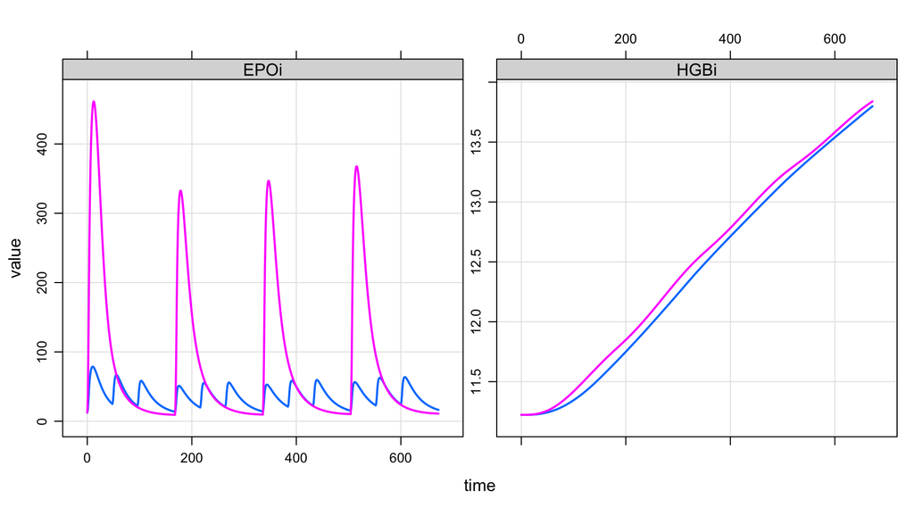

```r
mod %>%
  mrgsim(data = data_sc, end = 672) %>%
  plot(EPOi + HGBi~.)
```

```r
data_sc
```

```
.   time cmt   amt evid rate  ii addl    ID
. 1    0   1  7000    1   -2 168    3  7000
. 2   48   1  7000    1   -2 168    3  7000
. 3   96   1  7000    1   -2 168    3  7000
. 4    0   1 40000    1   -2 168    3 40000
```

```r
data_iv <- mutate(data_sc, cmt = 2, rate = 0)
data_iv
```

```
.   time cmt   amt evid rate  ii addl    ID
. 1    0   2  7000    1    0 168    3  7000
. 2   48   2  7000    1    0 168    3  7000
. 3   96   2  7000    1    0 168    3  7000
. 4    0   2 40000    1    0 168    3 40000
```

# 5 IV administration

- But when we look at the TIW versus QW comparison with IV administration, the once-weekly is less effective than three-times-weekly

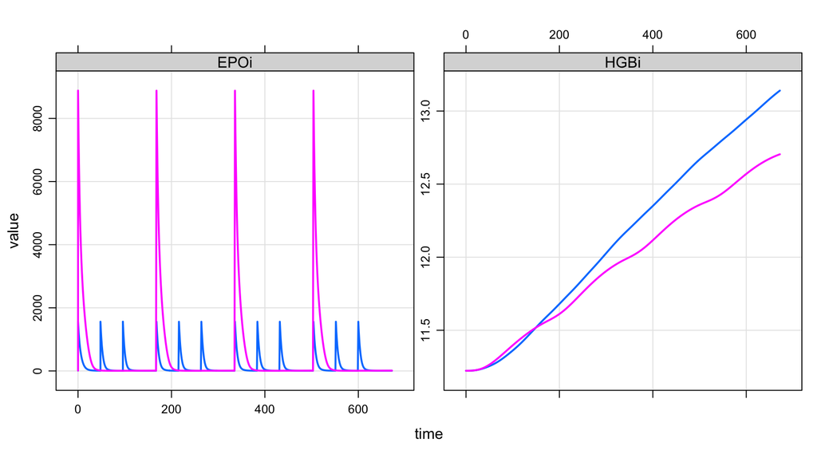

```r
mod %>%
  mrgsim(data = data_iv, end = 672) %>%
  plot(EPOi + HGBi~.)
```

# 6 Probability of technical success

Let’s look at the probability of technical success for the QW versus TIW dosing in the IV case

Let’s ramp this up for PTS

## 6.1 Population data sets

TIW data

```r
iv_tiw <- ev_rep(tiw, ID = 1:150) %>% mutate(cmt = 2, rate = 0)
```

QW data

```r
iv_qw <- filter(iv_tiw, time==0) %>% mutate(amt = 40000, ID = ID + 10000)
```

If we bind this all together, we can simulate both regimens in one go

```r
data <- bind_rows(iv_tiw, iv_qw) %>% mutate(qw = as.integer(amt==40000))

head(data)
```

```
.   time cmt  amt evid rate  ii addl ID qw
. 1    0   2 7000    1    0 168    3  1  0
. 2   48   2 7000    1    0 168    3  1  0
. 3   96   2 7000    1    0 168    3  1  0
. 4    0   2 7000    1    0 168    3  2  0
. 5   48   2 7000    1    0 168    3  2  0
. 6   96   2 7000    1    0 168    3  2  0
```

- What about simulating some variatility in Weight?

A simulation function

Arguments

- `i` replicate number
- `mod` the EPO model object
- `data` a template data set

```r
mod <- mread_cache("epo", "../model")
mod <- param(mod, THETA19 = mod$THETA19*0.8)

sim <- function(i, mod, data) {

  mod <- param(mod, slice(post,i))

  out <- mrgsim_d(mod, data = data, obsonly = TRUE,
                carry_out = "qw", end = -1, add = c(0,672), output="df")

  mutate(out, irep = i)
}
```

Test it out

```r
sim(2, mod, data) %>% head
```

```
.   ID time qw     RETdv      EPOi     RETi     RBCi      HGBi irep
. 1  1    0  0  18.40664 10.647644 29.02173 2.629851  7.401647    2
. 2  1  672  0 117.35489  6.250743 86.11372 3.131057  8.812279    2
. 3  2    0  0  23.23217 15.875975 32.78063 3.102982  9.024244    2
. 4  2  672  0  58.25028 13.029021 75.46734 3.543305 10.304813    2
. 5  3    0  0  30.67091 13.210942 28.57421 3.019639  9.233151    2
. 6  3  672  0 134.05238  8.814440 82.12835 3.598435 11.002936    2
```

## 6.2 Simulate

- Remember to set a seed
- What about uncertainty in the random effect variances?

```r
set.seed(10020)
out <- future_lapply(
  seq(500),
  sim, mod, data
) %>% bind_rows
```

## 6.3 Summarize

Our target is HGB > 10

```r
sum1 <-
  out %>%
  filter(time > 0) %>%
  group_by(irep,time,qw) %>%
  summarise(success = mean(HGBi >= 10), n = n())  %>%
  ungroup() %>%
  mutate(week = time/24/7)

sum1
```

```
. # A tibble: 1,000 x 6
.     irep  time    qw success     n  week
.    <int> <dbl> <dbl>   <dbl> <int> <dbl>
.  1     1   672     0   0.627   150     4
.  2     1   672     1   0.647   150     4
.  3     2   672     0   0.827   150     4
.  4     2   672     1   0.753   150     4
.  5     3   672     0   0.8     150     4
.  6     3   672     1   0.76    150     4
.  7     4   672     0   0.767   150     4
.  8     4   672     1   0.567   150     4
.  9     5   672     0   0.853   150     4
. 10     5   672     1   0.72    150     4
. # … with 990 more rows
```

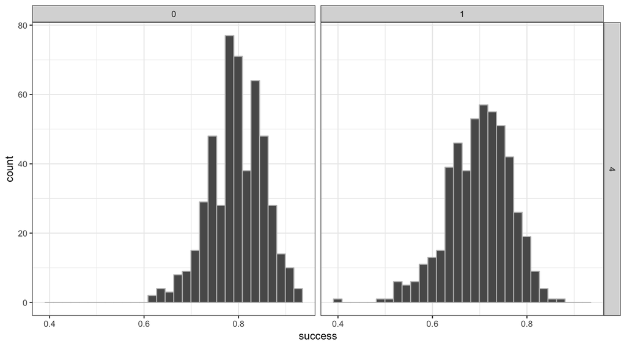

```r
ggplot(sum1, aes(x = success)) + geom_histogram(col="grey") +
  facet_grid(week~qw)
```

Our success criteria is at least 75% of patients hitting the target

```r
sum2 <-
  sum1 %>%
  group_by(week,qw) %>%
  summarise(PR = mean(success > 0.75))
```

The bottom line

```r
sum2
```

```
. # A tibble: 2 x 3
. # Groups:   week [1]
.    week    qw    PR
.   <dbl> <dbl> <dbl>
. 1     4     0 0.814
. 2     4     1 0.242
```